# Practice with Joins

Run the cells below to create the following dataframes.

df_purchases contains information on various customer purchases.

```python
import pandas as pd
from pandasql import sqldf

names = ["Jake", "Joe", "Ellen", "Joe", "Ellen"]
item = ["Ball", "Shirt", "Shoes", "Ball", "Shirt"]

df_purchases = pd.DataFrame({"Name": names, "Item_Purchased": item} )

df_purchases
```

|  | Item_Purchased | Name |
| --- | --- | --- |
| 0 | Ball | Jake |
| 1 | Shirt | Joe |
| 2 | Shoes | Ellen |
| 3 | Ball | Joe |
| 4 | Shirt | Ellen |

df_items contains information on the prices of each item.

```python
item = ["Ball", "Shirt", "Shoes"]
price = [10,15,75]

df_items = pd.DataFrame({"Item": item, "Price":price})

df_items
```

|  | Item | Price |
| --- | --- | --- |
| 0 | Ball | 10 |
| 1 | Shirt | 15 |
| 2 | Shoes | 75 |

df_customer contained information on the customers

```python
customers = ["Jake", "Joe", "Ellen"]
allowance = [15, 12, 85]

df_customers = pd.DataFrame({"Allowance":allowance, "Customers":customers})

df_customers
```

|  | Allowance | Customers |
| --- | --- | --- |
| 0 | 15 | Jake |
| 1 | 12 | Joe |
| 2 | 85 | Ellen |

**Question 1:** Write a query that selects all purchases made from the customer stored in the variable customer name

```python
customer_name = "Jake"

sqldf("SELECT * FROM df_purchases WHERE Name = '%s'" %customer_name)
```

|  | Item_Purchased | Name |
| --- | --- | --- |
| 0 | Ball | Jake |

**Question 2:** Write a query that selects all items priced above threshold_price.

```python
threshold_price=12

sqldf("SELECT * FROM df_items WHERE Price > %d" %threshold_price)
```

|  | Item | Price |
| --- | --- | --- |
| 0 | Shirt | 15 |
| 1 | Shoes | 75 |

**Question 3:** How many customers went over their allowance?

Create df_1, which is df_purchases with an additional column that gives the price of each item

```python
df_1 = sqldf("SELECT A.*, B.Price FROM df_purchases AS A JOIN \
                df_items AS B ON A.Item_Purchased = B.Item")

df_1
```

|  | Item_Purchased | Name | Price |
| --- | --- | --- | --- |
| 0 | Ball | Jake | 10 |
| 1 | Shirt | Joe | 15 |
| 2 | Shoes | Ellen | 75 |
| 3 | Ball | Joe | 10 |
| 4 | Shirt | Ellen | 15 |

Create df_2, which stores the total amount that each person spent.

```python
df_2 = sqldf("SELECT Name, SUM(Price) AS Total_Spent FROM df_1 GROUP BY Name")
df_2
```

|  | Name | Total_Spent |
| --- | --- | --- |
| 0 | Ellen | 90 |
| 1 | Jake | 10 |
| 2 | Joe | 25 |

Created df_3, which adds each person't allowance to df_2

```python
df_3 = sqldf("SELECT A.*, B.Allowance FROM df_2 AS A JOIN df_customers AS B ON A.Name = B.Customers")
df_3
```

|  | Name | Total_Spent | Allowance |
| --- | --- | --- | --- |
| 0 | Ellen | 90 | 85 |
| 1 | Jake | 10 | 15 |
| 2 | Joe | 25 | 12 |

Add a column to df_3 which tells whether or not they went over their allowance or not.

```python
df_3["Over"] = df_3["Total_Spent"]>df_3["Allowance"]
df_3
```

|  | Name | Total_Spent | Allowance | Over |
| --- | --- | --- | --- | --- |
| 0 | Ellen | 90 | 85 | True |
| 1 | Jake | 10 | 15 | False |
| 2 | Joe | 25 | 12 | True |

Compute how many people went over.

```python
num_over = sum(df_3["Over"])
num_over
```

```
2
```

# Fantansy Football Tool

In this practice, we will build a fantasy football tool that quickly let's us analyze the performance of any running back.

In the cell below import pandas, matplotlib and sqldf

```python
#Import relevant packages
import pandas as pd
import matplotlib.pyplot as plt
from pandasql import sqldf
```

Enter the running you would like to analyze below in the cell below as a string. If you don't know a running back use DeMarco Murray.

```python
#player_name = "LeVeon Bell"
#player_name = "DeMarco Murray"
player_name = "Arian Foster"
```

Read in the data from nflteams.csv, nflgames.csv, nflplayers.csv, and rushingstats.csv into dataframes

```python
#Read in the data
players = pd.read_csv("Data/Football_Data/nflplayers.csv")
teams = pd.read_csv("Data/Football_Data/nflteams.csv")
rushing_stats = pd.read_csv("Data/Football_Data/rushingstats.csv")
games  = pd.read_csv("Data/Football_Data/nflgames.csv")

teams.head(15)
```

|  | TeamID | TeamName | TeamCapsAbrv | TeamAbrv |
| --- | --- | --- | --- | --- |
| 0 | 1 | Baltimore Ravens | RAV | rav |
| 1 | 2 | Denver Broncos | DEN | den |
| 2 | 3 | Oakland Raiders | RAI | rai |
| 3 | 4 | Philadelphia Eagles | PHI | phi |
| 4 | 5 | Dallas Cowboys | DAL | dal |
| 5 | 6 | Jacksonville Jaguars | JAX | jax |
| 6 | 7 | Indianapolis Colts | CLT | clt |
| 7 | 8 | Washington Redskins | WAS | was |
| 8 | 9 | San Diego Chargers | SDG | sdg |
| 9 | 10 | Kansas City Chiefs | KAN | kan |
| 10 | 11 | New England Patriots | NWE | nwe |
| 11 | 12 | Tennessee Titans | OTI | oti |
| 12 | 13 | Houston Texans | HTX | htx |
| 13 | 14 | New York Giants | NYG | nyg |
| 14 | 15 | Carolina Panthers | CAR | car |

Get the PlayerID and TeamID corresponding to the inputted player.

```python
#Get the IDs for the given
playerInfo = sqldf("SELECT PlayerID, TeamID FROM players WHERE PlayerName = '%s'" %player_name)

player_id = playerInfo.loc[0, "PlayerID"]
player_team_id  = playerInfo.loc[0,"TeamID"]
```

Now pick out the rushing yards (Yds) and GameID for this player only for this player over all of his games.

```python
#Get the stats only for this player
rushing_stats_2 = sqldf("SELECT PlayerID, GameID, Yds FROM rushing_stats WHERE PlayerID = %d" %player_id)

rushing_stats_2
```

|  | PlayerID | GameID | Yds |
| --- | --- | --- | --- |
| 0 | 238 | 26 | 138 |
| 1 | 238 | 43 | 56 |
| 2 | 238 | 52 | 157 |
| 3 | 238 | 70 | 109 |
| 4 | 238 | 76 | 103 |
| 5 | 238 | 109 | 151 |
| 6 | 238 | 111 | 79 |
| 7 | 238 | 113 | 6 |
| 8 | 238 | 114 | 102 |

Join this with the games table to get the Week and Opponent teams ID.

```python
#Get week and opponenent ID
rushing_stats_3 = sqldf("SELECT A.*, B.Week, CASE WHEN B.HomeTeamID = %d THEN B.AwayTeamID ELSE B.HomeTeamID END AS OpponentID FROM rushing_stats_2 AS A\
                        JOIN games as B ON A.GameID = B.GameID" %player_team_id)

rushing_stats_3
```

|  | PlayerID | GameID | Yds | Week | OpponentID |
| --- | --- | --- | --- | --- | --- |
| 0 | 238 | 26 | 138 | 2 | 3 |
| 1 | 238 | 43 | 56 | 9 | 4 |
| 2 | 238 | 52 | 157 | 5 | 5 |
| 3 | 238 | 70 | 109 | 6 | 7 |
| 4 | 238 | 76 | 103 | 1 | 8 |
| 5 | 238 | 109 | 151 | 8 | 12 |
| 6 | 238 | 111 | 79 | 13 | 12 |
| 7 | 238 | 113 | 6 | 4 | 24 |
| 8 | 238 | 114 | 102 | 7 | 28 |

Join this with the teams dataframe to get the opponent abbreviation.

```python
rushing_stats_4 = sqldf("SELECT A.Week, B.TeamCapsAbrv As Opponent_Name, A.Yds FROM rushing_stats_3 AS A JOIN teams AS B ON A.OpponentID = B.TeamID ORDER BY Week ASC")
rushing_stats_4
```

|  | Week | Opponent_Name | Yds |
| --- | --- | --- | --- |
| 0 | 1 | WAS | 103 |
| 1 | 2 | RAI | 138 |
| 2 | 4 | BUF | 6 |
| 3 | 5 | DAL | 157 |
| 4 | 6 | CLT | 109 |
| 5 | 7 | PIT | 102 |
| 6 | 8 | OTI | 151 |
| 7 | 9 | PHI | 56 |
| 8 | 13 | OTI | 79 |

Now we create a line plot showing the yards gained over each week.

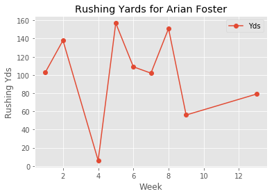

```python
%matplotlib inline

#Set to ggplot style
plt.style.use("ggplot")
#Create figure and axis
fig, ax  = plt.subplots()

#Add titles
ax.set(xlabel="Week", ylabel="Rushing Yds", title = "Rushing Yards for %s" %player_name )

rushing_stats_4.plot(kind="line", x="Week", y = "Yds", style="-o", ax=ax)
```

Next we add labels showing his opponents for the two games where he had the most rushing yards

```python
#Get info for top 2 games
top_2_games = sqldf("SELECT * FROM rushing_stats_4 ORDER BY Yds DESC LIMIT 2")

top_2_games
```

|  | Week | Opponent_Name | Yds |
| --- | --- | --- | --- |
| 0 | 5 | DAL | 157 |
| 1 | 8 | OTI | 151 |

Now let add the lables onto the graph.

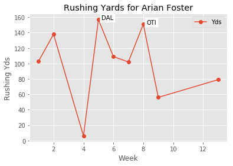

```python
#Add first label
ax.annotate(top_2_games.loc[0,"Opponent_Name"], xy = (top_2_games.loc[0,"Week"]+0.2, top_2_games.loc[0, "Yds"]), bbox = {"boxstyle" :"square", "fc": "white"})
ax.annotate(top_2_games.loc[1,"Opponent_Name"], xy = (top_2_games.loc[1,"Week"]+0.2, top_2_games.loc[1, "Yds"]), bbox = {"boxstyle" :"square", "fc": "white"})

#View the figure
fig
```